# Homework: Simulation

Muxin Hua

## Instructions

**Spend no more than 4 hours on writing pseudocode for this assignment**

Read the assignment from start to finish - the simulation design will affect your functions.

Work through this assignment in detailed pseudo-code first. See the hearts.Rmd file for an example. - Put your pseudo-code (or list of steps) in ``` blocks with no {} (this is a generic markup chunk).

Then, *if you have time*, implement the game in R and simulate your question.

You will have an opportunity to submit a link to this assignment with working code for an extra (bonus) homework assignment one week after this assignment is due.

When you are finished with the assignment:

1. Save the file as 10_Lastname_Firstname.Rmd and compile it
2. Commit the Rmd file and corresponding html file to your homework git repo
3. Push the commit to github
4. Locate the Rmd file on github and click on the SHA link for the file
5. Paste the url of the resulting page into Canvas to submit your assignment.

Your assignment must compile on a different computer.

## Is it in the cards?

In this task, you will create a simulation of a card game played with a standard deck of 52 cards. You might consider games such as [blackjack](https://bicyclecards.com/how-to-play/blackjack/#filter), [war](https://bicyclecards.com/how-to-play/war/#filter), or [go fish](https://bicyclecards.com/how-to-play/go-fish/#filter). You may choose any game that can be assessed probabilistically – you may want to avoid games which require a large amount of strategy, skill, and bluffing, such as poker. You may also want to avoid games which depend on pair strategies, such as spades.

This homework file is set up to demonstrate how this would be done with the game of [hearts](https://bicyclecards.com/how-to-play/hearts/#filter). As a result, you may not pick hearts as your game of choice.

You don’t need to necessarily simulate the full game mechanism, but you do need to implement enough of the game mechanism that you can identify an interesting probability question in your game and answer the question using a simulation.

### Set up your objects

First, you must set up a data frame describing all possible values of your playing items. For instance, if you are using a standard deck of 52 playing cards, you’ll need a data frame which has columns for suit and value, and you may want to make value a factor variable (your call on that one). If your game requires that players hold cards in their hand, you may also want to have a column indicating location (deck, discard, player_x).

```
Pseudocode steps

1. Create a tibble with 4 suits and 13 values labeled Ace, 2:10, J, Q, K
2. Add card ID numbers
3. Limited number of players to 2
4. Add location column
5. Add rank for comparison
```

```r
library(tidyverse)
create_deck <- function() {
  # Set up cards
  suits <- c("hearts", "diamonds", "spades", "clubs")

  values <- factor(1:13, labels = c(2:10, "Jack", "Queen", "King", "Ace"))
  deck <- crossing(suit = suits, value = values)

  # Set up points
  # This will change depending on which game you want to simulate
  # I have demonstrated this using hearts
  deck %>%
    # add a card ID
    mutate(id = 1:n()) %>%
    # add rank for comparing
    mutate(rank = rep(c(2:13,1), times=4))
}

create_deck()
```

```
## # A tibble: 52 × 4
##    suit  value    id  rank
##    <chr> <fct> <int> <dbl>
##  1 clubs 2         1     2
##  2 clubs 3         2     3
##  3 clubs 4         3     4
##  4 clubs 5         4     5
##  5 clubs 6         5     6
##  6 clubs 7         6     7
##  7 clubs 8         7     8
##  8 clubs 9         8     9
##  9 clubs 10        9    10
## 10 clubs Jack     10    11
## # … with 42 more rows
```

### Limit the number of players to 2

```r
check_player <- function(deck=create_deck(), n_player = 2){
  if (n_player == 2) {
      # do nothing special
    } else{
      stop("War is playable by only 2")
    }
  deck
}

create_deck() %>%
  check_player(n_player = 2) %>%
  arrange(value, suit)
```

```
## # A tibble: 52 × 4
##    suit     value    id  rank
##    <chr>    <fct> <int> <dbl>
##  1 clubs    2         1     2
##  2 diamonds 2        14     2
##  3 hearts   2        27     2
##  4 spades   2        40     2
##  5 clubs    3         2     3
##  6 diamonds 3        15     3
##  7 hearts   3        28     3
##  8 spades   3        41     3
##  9 clubs    4         3     4
## 10 diamonds 4        16     4
## # … with 42 more rows
```

### Write one or more functions to simulate the basic game mechanisms

For instance, if you are simulating a game where all cards are initially held by players, you need to have a function that randomly assigns 13 cards to each player. You may also want a function that controls the game play and functions for each separate step in game play (some of these functions may need to be called using a loop).

```
Pseudocode steps
1. Shuffle the card and devide the deck evenly, each player has 26 cards.
2. As long as cards are not labeled with the same player,the following loop goes on.
  2.1 Each of the player randomly pick a card from their stacks.
  2.2 compare the card.
    2.2.1 If the card are not the same rank, return the player has the higher rank.
    2.2.2 If the cards are the same rank, each player pick another two cards, turn up one randomly, and compare. If the rank are not the same, goes to the next step; if the rank are the same, redo this step.
  2.3 Winner takes all the cards selected by both players.
  2.4 Check if all the cards belong to one player, if not return to 2.1.
```

#### Break your problem down into steps and write functions for each step, putting each step under its own level 4 header (#### at the front)

#### Shuffle and divide

```r
# Shuffle the card and evenly divide 52 cards to 2 players, 26 cards each.
shuffle_div <- function(deck, player=1:2){
  deck %>% check_player(length(player)) %>%
    # shuffle the deck
    slice_sample(n = nrow(deck)) %>%
    # devide cards
    mutate(player = rep(player, length.out=n()))
}
create_deck() %>% shuffle_div()
```

```
## # A tibble: 52 × 5
##    suit     value    id  rank player
##    <chr>    <fct> <int> <dbl>  <int>
##  1 spades   3        41     3      1
##  2 clubs    3         2     3      2
##  3 clubs    7         6     7      1
##  4 clubs    Queen    11    12      2
##  5 spades   6        44     6      1
##  6 clubs    Jack     10    11      2
##  7 clubs    4         3     4      1
##  8 hearts   6        31     6      2
##  9 diamonds 6        18     6      1
## 10 diamonds 8        20     8      2
## # … with 42 more rows
```

#### Picking Cards

Since the players don’t need to know how their cards are arranged, so I set rule of randomly picking cards.

```r
# picking the number of cards need to be picked
# number of cards need to be picked depends on if the round before was a tie.
random_pick <- function(n_round){
  # create a vector storing the cards picked by players
  selected <- c()
  # pick cards for each player
  for (i in 1:2){
    picked <- create_deck() %>%
    shuffle_div() %>%
    filter(player == i) %>%  # limit the picking to a specific player
    slice_sample(n = (ifelse(n_round==1, 1, 2))) # pick 1 or 2 cards depend on if there were same rank in the round before
    selected <- rbind(selected, picked)
  }
  return(selected)
}
```

#### Compare the cards

```r
# No matter how many selected (1 or 2), randomly pick one for comparing
compare <- function(selected, tie=0){
  winner=0
  # select the card for comparing
  select_1 <- selected %>% filter(player==1) %>% slice_sample(n = 1)
  select_2 <- selected %>% filter(player==2) %>% slice_sample(n = 1)
  # compare the selected cards to decide winner and tie
  if(select_1$rank>select_2$rank){
    winner=1
    tie=0}
  else if(select_1$rank>select_2$rank){
      winner=2
      tie=0}
  else{tie <- tie+1} # if this is a tie, add one to variable tie
  return(c(winner, tie))
  }
```

#### Winner takes all the cards

```r
take_cards <- function(deck, all_selected, winner){
  # assigning all the cards in selected as cards of the winner
  all_selected$player <- rep(winner,times=nrow(all_selected))
  # relable those cards in the original deck
  deck <- rbind(deck[-c(all_selected$id),], all_selected)
  return(deck)
}
```

#### Play a full game

```r
general_play <- function(total_round){
  # create a deck, shuffle and divide
  stacks <- create_deck() %>% shuffle_div()
  n_count = 1 # Total number of comparisons
  # As long as both player have cards, the game can go on
  while (!((sum(stacks$player == 1)==0) || (sum(stacks$player == 2)==0))){
    n_tie <- 0
    tie <- 0
    n_round <- 1 # how many comparisons before a player takes all the cards
    all_selected <- random_pick(n_round)
    res <- compare(all_selected, tie)
    winner <- res[1]
    tie <- res[2]
    # If there's a tie in the first comparison, the selection and comparing loop has to go on before find a real winner
    while(tie != 0){
      n_tie <- n_tie + 1
      n_round <- n_round + tie
      round_selected <- random_pick(n_round)
      all_selected <- rbind(round_selected, all_selected)
      res <- compare(round_selected, tie)
      winner <- res[1]
      tie <- res[2]
    }
    n_count <- n_count+n_round
    take_cards(stacks, all_selected, winner)
    if (n_count>=total_round){break} # It takes thousands of round to finish playing this game, so I limited the game to the a number assigned by user
  }
  return(c(n_tie, n_count)) # Return how many ties are their in the whole game
}
```

#### Full Simulation

I run 1000 times for each round limitation of 10, 100 and 500, to see what are the percentage of tie in the game.

```r
total_percentage <- c()
for (total_round in c(10, 100, 500)){
  tie_percentage <- c()
  i=1
  while (i <= 1000){
    rest <- general_play(total_round)
    tie_percentage <- rbind(tie_percentage, rest)
    i <- i+1
    }
  total_percentage <- rbind(total_percentage, tie_percentage)
}
```

```r
save(total_percentage, file = "total_percentage.Rdata")
```

### Identify a probability question you can answer with your simulation

#### Does the total number of same-rank case varies with the total number of games played?

To answer this question, I plot the statistical distribution of the number of ‘same-rank case’ as follow. The simulation shows that the number of ‘same-rank case’ looks independent of the game played.

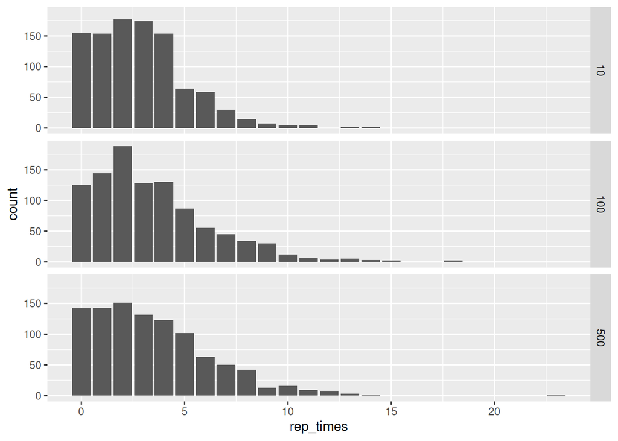

```r
load("total_percentage.Rdata")
total_percentage <- cbind(data.frame(total_percentage), rep(c('10', '100', '500'), each=1000))
colnames(total_percentage) <- c('rep_times', 'all_rounds', 'mark')
rownames(total_percentage) <- c(1:nrow(total_percentage))

ggplot(total_percentage, aes(x=rep_times))+geom_bar()+facet_grid(mark ~ .)
```